# R Notebook

# Statistics II Homework Ch5_Textbook

## 9.29

### a

```r
pnorm(12,mean=10,sd=3,lower.tail = FALSE)
```

```
[1] 0.2524925
```

### b

mean number of pizzas consumed by 25 students = 10 standard deviation = 3/ {sqrt(25)} = 0.6

```r
m = 275/25
pnorm(m,10,sd=0.6,lower.tail = FALSE)
```

```
[1] 0.04779035
```

## 9.35

mean weight of the 16 people = 75 standard deviation =10/{sqrt(16)} = 2.5

```r
m = 1140/16
pnorm(m,75,sd=2.5,lower.tail = FALSE)
```

```
[1] 0.9331928
```

## 9.51

n = 1000 p = 0.3 np = 300 > 5 n(1-p) = 700 > 5 so z = (^p-p)/sqrt(p*(1-p)/n) = (0.32-0.3)/sqrt(0.3*0.7/1000)

```r
z = (0.32-0.3)/sqrt(0.3*0.7/1000)
p = pnorm(z,lower.tail = FALSE)
cat("z = ", z,"\nP(^p > .32) = ",p)
```

```
z =  1.380131
P(^p > .32) =  0.08377314
```

## 9.53

n = 350 p = 0.8 np = 280 > 5 n(1-p) = 70 > 5 so z = (^p-p)/sqrt(p*(1-p)/n) = (.75-.8)/sqrt(.8*(.2)/350)

```r
z = (.75-.8)/sqrt(.8*(.2)/350)
p = pnorm(z)
cat("z = ", z,"\nP(^p < .75) = ",p)
```

```
z =  -2.338536
P(^p < .75) =  0.009679734
```

# hw_ch9

## data pre-processing:

```r
genpop1=function(size=10000, mixprob=0.6, m1=100, sd1=10, m2=150, sd2=20) {
    tmpseed = .Random.seed
    set.seed(5523)
    #flip coins with mixprob success prob.
    coin1 = runif(size) < mixprob

    rn1 = rnorm(size, m1, sd1)
    rn2 = rnorm(size, m2, sd2)

    rnfinal = rn2
    rnfinal[coin1] = rn1[coin1]
    .Random.seed = tmpseed
    return(rnfinal)
    plot(size,rnfinal,type = 'l',ylim = c(0,max(genpop1(),genpop2())))
}
genpop2 = function(size=12000, lambda=140) {
    tmpseed = .Random.seed
    set.seed(5524)
    tmp1 = rpois(size, lambda)
    .Random.seed = tmpseed
    return(tmp1)
}
set.seed(1001) #to get .Random.seed defined.
pop1 = genpop1()
pop2 = genpop2()
```

## 1

算出兩個母體的平均數和標準差

```r
mean_p1 = mean(pop1)
sd_p1 = sqrt(var(pop1))
mean_p2 = mean(pop2)
sd_p2 = sqrt(var(pop2))
cat("P1:\n size = 10000\n","mean = ",mean_p1,"\n standard deviation = ",sd_p1)
```

```
P1:
 size = 10000
 mean =  120.2431
 standard deviation =  28.68657
```

```r
cat("\nP2:\n size = 12000\n","mean = ",mean_p2,"\n standard deviation = ",sd_p2)
```

```
P2:
 size = 12000
 mean =  139.8814
 standard deviation =  11.87809
```

from the result, we found that the mean of pop2 is bigger than that of pop1. Also, the size of pop2 is bigger, but the standard deviation of pop2 is smaller. ->pop1 is more scattered than pop2.

## 2

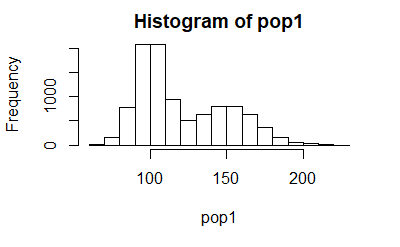

```r
hist(pop1)
```

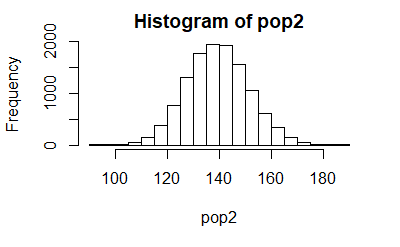

```r
hist(pop2)
```

## 3

based on the sampling distribution properties, the mean of(x1-x2) = mean of pop1 - mean of pop2 standard deviation = sqrt(sd1<sup>2/n1+sd2</sup>2/n2)

```r
n1 = 100
n2 = 50
m_3 = mean_p1 - mean_p2
sd_3 = sqrt(sd_p1^2/n1+sd_p2^2/n2)
cat("when n1 = 100 n2 = 50\nmean = ", m_3,"\nstandard deviation = ",sd_3)
```

```
when n1 = 100 n2 = 50
mean =  -19.63828
standard deviation =  3.3243
```

from the result, we know that the mean would not differ from the sample size.

## 4

```r
set.seed(5000)
dlist = c()
for(i in 1:50){
  s1 = sample(pop1, 100, replace = FALSE)
  s2 = sample(pop2, 50, replace = FALSE)
  d = mean(s1)-mean(s2)
  dlist[i] = d
}
m_4 = mean(dlist)
sd_4 = sd(dlist)
cat("mean:",m_4," \nstandard deviation:",sd_4)
```

```
mean: -19.62614
standard deviation: 3.879541
```

## 5

```r
run = c(50,100,500,1000,5000,10000,50000)
mofrun = vector(mode = "numeric", length = 7)
sdofrun = vector(mode = "numeric", length = 7)
cnt = 1
for(i in 1:7)
{
  for(i in 1:run[cnt]){
  s1 = sample(pop1, 100, replace = FALSE)
  s2 = sample(pop2, 50, replace = FALSE)
  d = mean(s1)-mean(s2)
  dlist[i] = d
  }
  mofrun[cnt] = mean(dlist)
  sdofrun[cnt] = sd(dlist)
  cat("nrun = ", run[cnt],",mean = ",mofrun[cnt],",standard deviation = ",sdofrun[cnt],"\n")
  cnt = cnt + 1
}
```

```
nrun =  50 ,mean =  -19.63724 ,standard deviation =  3.300979
nrun =  100 ,mean =  -19.6376 ,standard deviation =  3.30065
nrun =  500 ,mean =  -19.63585 ,standard deviation =  3.303704
nrun =  1000 ,mean =  -19.63734 ,standard deviation =  3.302376
nrun =  5000 ,mean =  -19.63859 ,standard deviation =  3.304277
nrun =  10000 ,mean =  -19.63676 ,standard deviation =  3.297355
nrun =  50000 ,mean =  -19.64114 ,standard deviation =  3.323202
```

the more times we run, the result seems not to be exactly closer to a fixed number.